# Project_1

Tatiana Maslikova

30 10 2019

### 1) Пользовательска функция для объединения наблюдений в единую таблицу

Для объединения данных от нескольких наблюдателей в одну общую таблицу была написана функция `combine_csv()`.

```r
combine_csv <- function(my_path = '.'){
  library(plyr)
  library(reshape)
  filenames <- list.files(path= my_path, full.names=TRUE)
  import.list <- llply(filenames, read.csv)
  data <- merge_recurse(import.list)
}
```

### 2) Предобработка данных

После просмотра структуры данных становится понятно, что у некоторых переменных некорректно задан их тип.

Переменная `Rings` отражает количество колец у улитки, а переменная `Length` - длину улитки, но в датасете эти переменные соответсвуют типу `character`. Эти количественные по своей сути переменные были приведены к типу `numeric`.

Так же в новую переменную `Lenght_z_scores` были сохранены значения переменной `Length` после её стандартизации *(пункт 6 из задания)*

Переменная `Sex` по умолчанию текстовая (тип `character`), но её значения соответсвуют цифрам, что подразумевает факторность (в заголовке переменной описано соответствие цифры полу особи). Однако, при переводе переменной в фактор оказывается, что уровня у фактора не 3, как ожидалось (`"female", "uvenil", "male"`), а 6:

```
[1] "1"     "2"     "3"     "male"  "one"   "three"
```

Так как по сути тут всего три уровня, переменная была риведена к факторному виду с тремя уровнями: `"male", "female", "uvenil"`.

У всех переменных, кроме количества колец, имеются пропущенные значения. Такие наблюдения были выброшены из общей таблицы, т.к. они составляют крайне малый процент от всех наблюдений (1.4%).

### 3) Статистики длины моллюсков разного пола.

| Sex | mean | sd | n |
| --- | --- | --- | --- |
| male | 0.5612558 | 0.1005945 | 1509 |
| female | 0.5788110 | 0.0859223 | 1291 |
| uvenil | 0.4303222 | 0.1070619 | 1319 |

### 4) У какого процента моллюсков значение переменной Height не превышает 0.165?

У 28.6% моллюсков высота не превышает 0.165.

### 5) Чему равняется значение переменной Length, которое выше чем у 92% от всех наблюдений?

Pначение переменной Length, которое выше чем у 92% от всех наблюдений, не меньше 0.67

### 7) Сравнение диаметра моллюсков с числом колец 5 и 15.

| Rings | mean | sd | n |
| --- | --- | --- | --- |
| 5 | 0.2122072 | 0.0471443 | 111 |
| 15 | 0.4562621 | 0.0590228 | 103 |

Согласно информации из таблицы, средний диаметр моллюсков с 5 кольцами отличается от такового у моллюсков с 15 кольцами в 2.2 раза.

Чтобы выбрать статистический тест для проверки значимости этих результатов необходимо проверить данные на нормальность рапсределения. Согласно тесту нормальности Шапиро-Уилка, величины диаметра панциря с 5 кольцами и с 15 кольцами распределены нормально (p-value = 0.14 > 0,05 для 5 колец, и p-value = 0.18 > 0,05 для 15 колец), а значит можно применить t-тест.

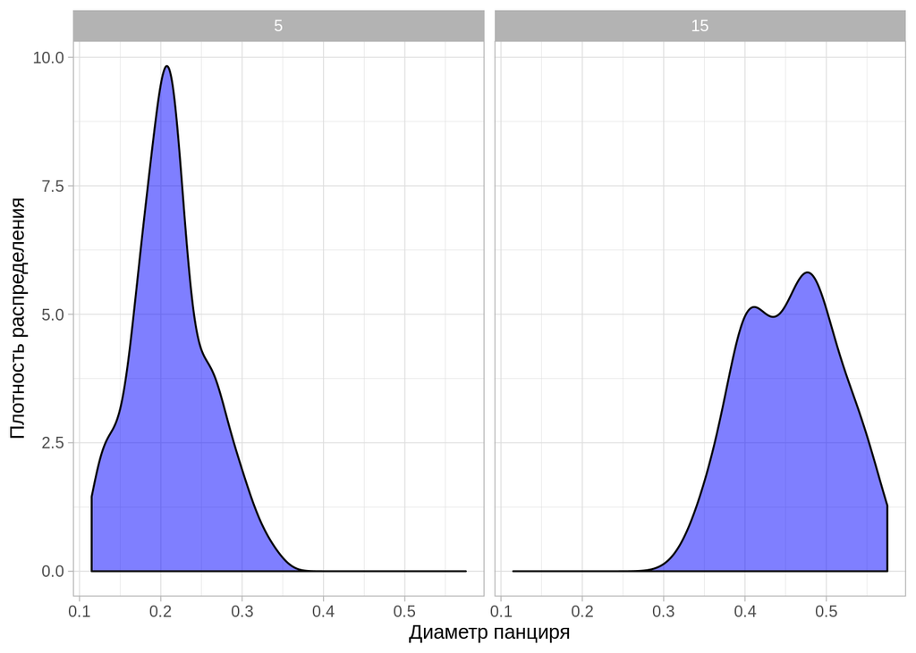

Cогласно t-тесту диаметры раковин с разным количеством колец (5 и 15) достоверно различаются (p-value = 2.491035510^{-82}; значение t-статистики: -33; количество степеней свободы: 195).

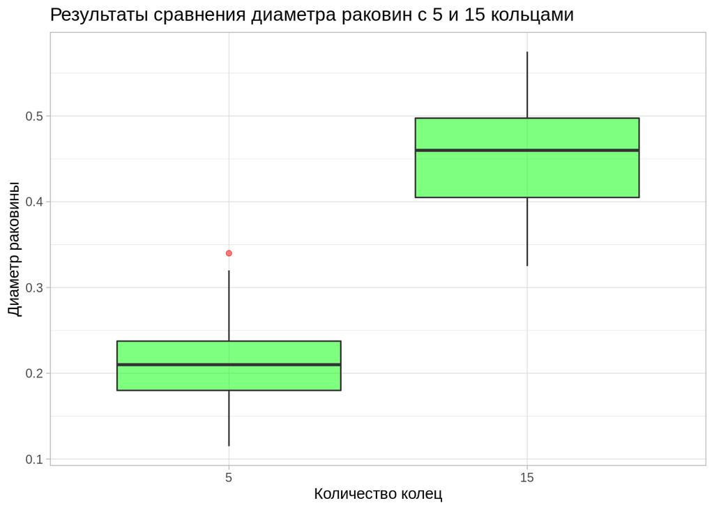

### 8) Анализ и взаимосвязь диаметра ракушки и общего веса

#### Анализ диаметра панциря улитки

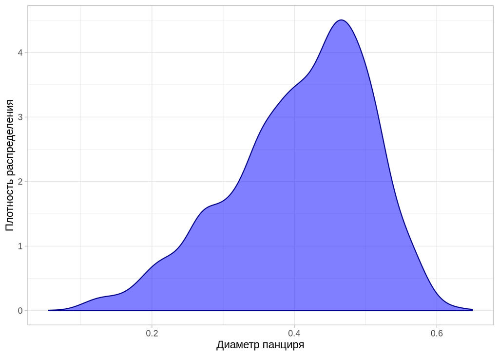

#### Анализ веса улиток

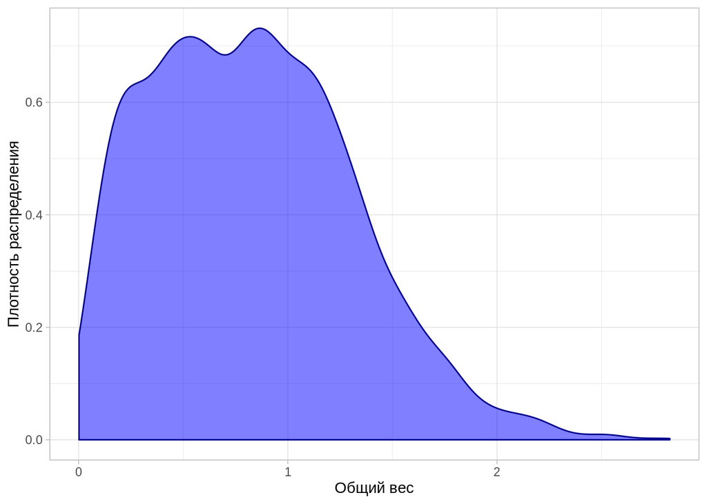

#### Оценка взаимосвязи диаметра панциря и веса улиток

Так как такие показатели, как диаметр панциря и общий вес, распределены не нормально, для оценки корреляции был использован коэффициент корреляции Спирмена. При p < 0.05 (p-value = 0) была принята гипотеза о том, что между этими характеристиками положительная нелинейная связь (*rho* = 0.971), а именно экспоненциальная регрессия.

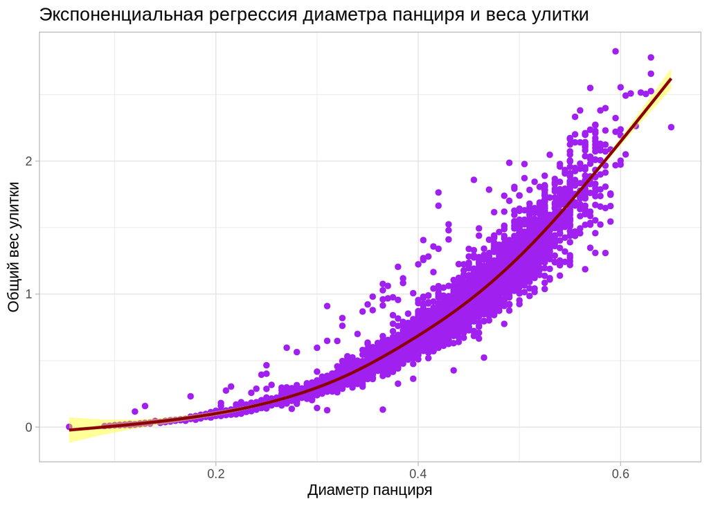

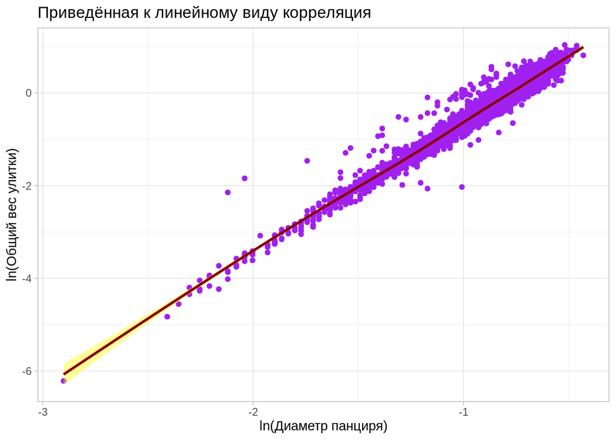